# Do you want to go on a camel-ride to explore the world of OCaml?

Your beginner-friendly practical guide to exploring OCaml, understanding a real codebase, and getting started with open-source contributions.

OCaml

Open Source Software

Open Data

Open Science

Free Software

Software

Functional Programming

Geospatial

Research Software

Meta data

Outreachy

This blog post is a practical guide to exploring OCaml, understanding a real codebase, and getting started with open-source contributions.

Jyoti Bhogal https://jyoti-bhogal.github.io/about-me/  
10-23-2026

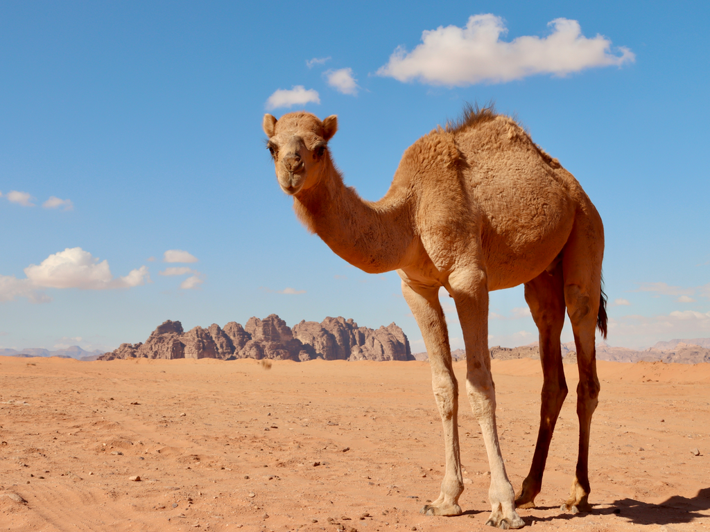

Photo by [Hongbin](https://unsplash.com/@hbsun2013?utm_source=unsplash&utm_medium=referral&utm_content=creditCopyText) on [Unsplash](https://unsplash.com/photos/a-camel-standing-in-the-middle-of-a-desert-heNpLRaLDNw?utm_source=unsplash&utm_medium=referral&utm_content=creditCopyText)

Have you ever opened a new code repository and wondered where to begin? What do all these folders and files mean? Where should I look first? And how do I start contributing?

I had similar questions when I began exploring [OCaml](https://ocaml.org/) and the geocaml/ocaml-tiff repository.

While exploring the codebase, a few fellow contributors also reached out to me for help understanding its structure. So, I thought, why not put together everything I’ve learned in one place and share it with everyone?

Our friendly camel 🐪 would be really happy to take you on this exploration journey!

So, hop on! Let’s go for a ride!

## Meet OCaml and its camel 🐪

OCaml is a high-level, statically typed programming language that supports functional, imperative, and object-oriented programming.

The OCaml community contributes to the implementation of the language, as well as its growing ecosystem of tools and libraries.

### What did I find interesting about OCaml?

I explored videos from the **FUN OCaml conference**, where I learned about how OCaml is used in academic research, industry, and software development, along with the scientific ideas behind the language.

One interesting talk was [Frameworks: No, Libraries: Yes. Developing a Product in OCaml from Scratch - FUN OCaml 2025 by Malcolm Matalka](https://www.youtube.com/watch?v=0Hwd7NxQ8_c) and the playlist [OCaml Unboxed by the wonderful folks at Jane Street](https://youtube.com/playlist?list=PLCiAikFFaMJrgFrWRKn0-1EI3gVZLQJtJ&si=DjFJDauYix2B36tO).

Coming from a background in R, Python, and scientific data analysis, I was curious to explore how OCaml is used in research and software.

## Getting started with OCaml

Before diving into the code, let’s get familiar with a few tools.

The `ocaml-tiff` project uses the [Dune build system](https://ocaml.org/docs/using-the-ocaml-compiler-toolchain) and the [opam package manager](https://ocaml.org/docs/managing-dependencies).

- **Dune** helps build and test OCaml projects.
- **opam** helps manage OCaml packages and development environments.
- **utop** provides an interactive environment for experimenting with OCaml code right into your terminal window.

If you’re new to OCaml, these resources are a great starting point:

- [How to Install OCaml](https://ocaml.org/docs/installing-ocaml)
- [Take a Tour of OCaml](https://ocaml.org/docs/tour-of-ocaml)
- [Write Your First OCaml Program](https://ocaml.org/docs/your-first-program)

I also experimented with OCaml using `utop` in my VS Code terminal. It was a useful way to understand the syntax and observe how the language behaves.

To try it yourself - paste the following commands in your terminal:

```bash
opam install utop
utop
```

And here’s a small experiment:

```
let square x = x * x;;
square 5;;
```

You should get `25` as the result!

## Let’s explore the ocaml-tiff repository!

Are you already feeling inspired to contribute?

Start with the project’s CONTRIBUTING.md guide and follow the setup instructions.

Once your local environment is ready, let’s understand how the repository is organized.

### What’s inside the folders?

Here are five important folders in the root directory.

| Sr. No. | Folder name | Folder Content | What does the folder do? (Layman edition/Newcomer edition) | What do these files do? |
| --- | --- | --- | --- | --- |
| 1 | **`src/`** | Main source code | Builds the functionality | Contains the OCaml code responsible for understanding TIFF files and their contents. |
| 2 | **`test/`** | Tests | Checks that the functionality works | Contains tests and sample TIFF files that help catch errors when code changes. |
| 3 | **`examples/`** | Example programs | Shows how to use it | Demonstrates how other programs can use the library. |
| 4 | **`bench/`** | Benchmarks | Measures performance | Measures how efficiently the library performs operations. |
| 5 | **`fuzz/`** | Robustness testing | Finds problems with unusual inputs | Helps identify crashes and unexpected behaviour. |

**My tip:** Start with the `README.md`, then explore `examples/` and `test/` before diving into the source code.

### What are the other files in the root directory?

| Sr. No. | File | What it does? |
| --- | --- | --- |
| 1 | **`README.md`** | Introduces the project and its usage. |
| 2 | **`HACKING.md`** | Explains technical and development details. |
| 3 | **`CONTRIBUTING.md`** | Provides instructions for contributors. |
| 4 | **`dune-project`** | Defines the project and package configuration. |
| 5 | **`dune`** | Configures build behaviour. |
| 6 | **`tiff.opam`** | Contains package metadata and dependencies. |
| 7 | **`tiff.opam.template`** | Template for package metadata. |
| 8 | **`.ocamlformat`** | Defines OCaml code formatting rules. |
| 9 | **`.gitignore`** | Tells Git which files to ignore. |
| 10 | **`.gitattributes`** | Configures how Git handles certain files. |
| 11 | **`LICENSE`** | Specifies the software’s licensing terms. |

### What do the different file extensions mean?

This was one of the first things I wanted to understand when exploring the repository.

| Sr. No. | File type | Meaning | Familiar comparison with a Python project |
| --- | --- | --- | --- |
| 1 | **`.ml`** | OCaml implementation code | `.py` in Python or `.R` in R |
| 2 | **`.mli`** | Defines a module’s public interface | Similar to an API declaration or header file |
| 3 | **`.md`** | Markdown documentation | GitHub README |
| 4 | **`.tiff`** | Image file, often used for testing | Sample dataset |
| 5 | **`.opam`** | Package metadata and dependencies | Package manifest |
| 6 | **`.ocamlformat`** | Code formatting configuration | Python formatter configuration |
| 7 | **`.gitignore`** | Git ignore rules | Same concept in Python projects |
| 8 | **`.gitattributes`** | Git file-handling rules | Git configuration |

You don’t need to understand every file immediately. Recognising what each file is for is already a useful first step!

## From exploration to contribution: A little about my journey

Once I understood the repository structure, I began exploring [Issue #81: Structured Error Reporting](https://github.com/geocaml/ocaml-tiff/issues/81).

The issue involved improving how the library handles and reports errors.

I started by asking questions: Where are errors raised? How are they handled? Which files contain the relevant code?

This helped me identify the relevant parts of the codebase and gradually understand how they worked.

Interestingly, while setting up the project, I also encountered a problem that turned out to be a bug. I reported it, worked on a 1-line fix, and submitted [Pull Request #94](https://github.com/geocaml/ocaml-tiff/pull/94), which was merged!

I shared the fix with other contributors, hoping it would make their setup experience easier.

I also started working on [structured error reporting](https://github.com/geocaml/ocaml-tiff/pull/106) and [documentation improvements](https://github.com/geocaml/ocaml-tiff/pull/107).

**My biggest takeaway?** You don’t always need to understand an entire codebase before contributing. Sometimes, the process of getting started reveals something useful that you can improve for everyone.

## Your turn! Where will the camel take you next? 🐪

Now that you’ve explored the language, its tools, and the repository structure, why not try something yourself?

Here’s a small challenge:

1. **Reproduce existing examples:** Check out the [Your First Program](https://ocaml.org/docs/your-first-program) learning page from the OCaml.org official website and write your first program using the OCaml language.
2. **Explore:** Open the [ocaml-tiff repository](https://github.com/geocaml/ocaml-tiff) and find a function inside `src/`.
3. **Experiment:** Try running a small OCaml program using `utop`.
4. **Investigate:** Look at the tests and see how the project checks that its functions work.
5. **Contribute:** Browse the [open issues](https://github.com/geocaml/ocaml-tiff/issues?q=is%3Aissue+state%3Aopen). Is there something you’d like to explore further?

And remember, your journey doesn’t need to stop at this repository!

Explore the [OCaml community](https://ocaml.org/community), browse the [OCaml GitHub organisation](https://github.com/ocaml), or discover more learning resources on [OCaml.org](https://ocaml.org/).

You might find an interesting project, learn a new programming concept, or meet people who are exploring similar questions.

### **One last thought**

When I first started exploring OCaml, I had more questions than answers. And I still have plenty of questions!

But every question has helped me discover something new, whether about the language, the repository, or the people contributing to it.

> You don’t have to understand everything to get started. Start small, stay curious, and share what you learn along the way.

So, where will your next camel ride take you?

[figure not shown]

The Turing Way Community, & Scriberia. (2023). Illustrations from The Turing Way: Shared under CC-BY 4.0 for reuse [Figure]. Zenodo. https://doi.org/10.5281/zenodo.7587336

Happy exploring! 🐪📚

## Get In Touch:

**Email:** bhogaljyoti1@gmail.com  
**LinkedIn:** jyoti-bhogal  
**GitHub:** jyoti-bhogal  
**Mastodon:** jyoti_bhogal

**Bluesky:** jyoti-bhogal.bsky.social

**Website:** https://jyoti-bhogal.github.io/about-me/index.html